# PREDICTING THE STATUS OF HEART DISEASE BASED ON LIFESTYLE, ENVIROMENTAL FACTORS AND HEATH CHARACTERISTICS. A MACHINE LEARNING APPROACH

By

KEHINDE RICHARD OLUWASEUN (Richie Mighty)

## Introduction to Placement and Problem Area

## Placement Description: Machine Leaning and Data Visualization

In the area of Big Data analysis, powerful tools include machine learning and data visualization. Data visualization offers clear, interactive representations of complicated information, while machine learning enables the automatic extraction of patterns and insights from vast datasets. Together, they improve comprehension and judgment. Hastie et al. (2009) claim that machine learning algorithms enable the creation of prediction models, while Tufte (2001) underlines the significance of correct data visualization in information dissemination.

According to World Health Organization (2022), cardiovascular diseases (CVDs) are the leading cause of death globally, taking an estimated 17.9 million lives each year. CVDs are a group of disorders of the heart and blood vessels and include coronary heart disease, cerebrovascular disease, rheumatic heart disease and other conditions. More than four out of five CVD deaths are due to heart attacks and strokes, and one third of these deaths occur prematurely in people under 70 years of age (World Heath Organization, 2022).

Heart disease is the leading cause of death for men, women, and people of most racial and ethnic groups in the United States, and it has been recorded by the Centre for Disease Control and Prevention (CDCP) that one person dies every 34 seconds in the United States from heart disease (Centre for Diseases Control and Prevention, 2022).

The healthcare sector has long been an early adopter of technological advances. These days, machine learning, a subset of artificial intelligence, plays a key role in many health innovations, including the development of new medical procedures, the handling of patient records and the treatment of chronic diseases (Thomas, 2022).

## Objectives of the Placement

• To describe the dataset with descriptive analysis and visualizations.

• To investigate the effect of various lifestyle indicators, environmental factors and clinical characteristics on the risk of heart diseases.

• To build machine learning models that predicts the heart diseases status of an individual based on their other clinical and demographics characteristics.

## About the Data Set

The dataset to be used for this project is a heart disease dataset obtained from a free and open-source data website. Originally, the dataset comes from the CDC and is a major part of the Behavioral Risk Factor Surveillance System (BRFSS), which conducts annual telephone surveys to gather data on the health status of U.S residents. As the CDC describes: Established in 1984 with 15 states, BRFSS bow collects data in all 50 states as well as district od Columbia and three U.S territories. BRFSS completes more than 400,000 adult interviews each year, making it the largest continuously conducted health survey system in the world”. The most recent dataset (as of February 15, 2020) incudes data from 20202. It consists of 401, 958 rows and 279 columns. The vast majority of the columns are questions asked from respondents about their health status, such as smoking status, difficulty in walking or climbing stairs, and others, but the 18 most relevant questions or variables that most directly or indirectly influence he risk of heart diseases was filtered out from the enormous dataset. Therefore, the heart diseases data to be used in the study consist of 18 columns and 319,795 observations, and be accessed at https://www.kaggle.com/datasets/kamilpytlak/personal-key-indicators-of-heart-disease

## Machine Learning Algorithm to be used

In this placement, various machine learning classification algorithms was used to model and make predictions on the dataset. They include:

• Logistics Regression

• Random Forest Classifier

• Decision Tree Classifier and

• Naïve Bayes Classifier.

## Steps Involved

Firstly, the data set was loaded into Python, on Jupyter notebook, and the dataset undergo preprocessing at first stage, where the data was studied, cleaned and preprocessed to ensure its quality and suitability for machine learning algorithms. This involves handling missing values, removing outliers, and normalizing or standardizing features.

The second stage is the Exploratory Data Analysis (EDA) stage where the dataset was explored using lots of visualizations including pie chart, bar plots, histograms, boxplots and many more. This helps us to understand how patients clinical, social and lifestyle influences each other.

The last steps and stage of the project is the building of the machine learning models. This process involves scaling the dataset, splitting the data sets into training and testing sets, thereby, training the training set and using the model trained to predict and test the testing set.

## Importing required libraries

```python
# Importing required libraries
import warnings
warnings.filterwarnings('ignore')

import pandas as pd
import numpy as np
import matplotlib.pyplot as plt
import seaborn as sns
plt.style.use('ggplot')
from sklearn.preprocessing import LabelEncoder
### Classifiers and Predictions
from sklearn.preprocessing import StandardScaler
from sklearn.model_selection import cross_validate
from sklearn.model_selection import RandomizedSearchCV
from sklearn import svm
from sklearn import metrics
```

## Loading the heart diseases data set

```python
df = pd.read_csv('heart_2020_cleaned.csv')
df.head(10)
```

|  | HeartDisease | BMI | Smoking | AlcoholDrinking | Stroke | PhysicalHealth | MentalHealth | DiffWalking | Sex | AgeCategory | Race | Diabetic | PhysicalActivity | GenHealth | SleepTime | Asthma | KidneyDisease | SkinCancer |
| --- | --- | --- | --- | --- | --- | --- | --- | --- | --- | --- | --- | --- | --- | --- | --- | --- | --- | --- |
| 0 | No | 16.60 | Yes | No | No | 3.0 | 30.0 | No | Female | 55-59 | White | Yes | Yes | Very good | 5.0 | Yes | No | Yes |
| 1 | No | 20.34 | No | No | Yes | 0.0 | 0.0 | No | Female | 80 or older | White | No | Yes | Very good | 7.0 | No | No | No |
| 2 | No | 26.58 | Yes | No | No | 20.0 | 30.0 | No | Male | 65-69 | White | Yes | Yes | Fair | 8.0 | Yes | No | No |
| 3 | No | 24.21 | No | No | No | 0.0 | 0.0 | No | Female | 75-79 | White | No | No | Good | 6.0 | No | No | Yes |
| 4 | No | 23.71 | No | No | No | 28.0 | 0.0 | Yes | Female | 40-44 | White | No | Yes | Very good | 8.0 | No | No | No |
| 5 | Yes | 28.87 | Yes | No | No | 6.0 | 0.0 | Yes | Female | 75-79 | Black | No | No | Fair | 12.0 | No | No | No |
| 6 | No | 21.63 | No | No | No | 15.0 | 0.0 | No | Female | 70-74 | White | No | Yes | Fair | 4.0 | Yes | No | Yes |
| 7 | No | 31.64 | Yes | No | No | 5.0 | 0.0 | Yes | Female | 80 or older | White | Yes | No | Good | 9.0 | Yes | No | No |
| 8 | No | 26.45 | No | No | No | 0.0 | 0.0 | No | Female | 80 or older | White | No, borderline diabetes | No | Fair | 5.0 | No | Yes | No |
| 9 | No | 40.69 | No | No | No | 0.0 | 0.0 | Yes | Male | 65-69 | White | No | Yes | Good | 10.0 | No | No | No |

### Checking the Number of rows and columns

# PART A: DATA PREPROCESSING

```python
print('Number of rows : ', df.shape[0])
print('Number of Columns : ', df.shape[1])
```

```
Number of rows :  319795
Number of Columns :  18
```

```python
# Checking informations about the dataset
df.info()
```

```
<class 'pandas.core.frame.DataFrame'>
RangeIndex: 319795 entries, 0 to 319794
Data columns (total 18 columns):
 #   Column            Non-Null Count   Dtype
---  ------            --------------   -----
 0   HeartDisease      319795 non-null  object
 1   BMI               319795 non-null  float64
 2   Smoking           319795 non-null  object
 3   AlcoholDrinking   319795 non-null  object
 4   Stroke            319795 non-null  object
 5   PhysicalHealth    319795 non-null  float64
 6   MentalHealth      319795 non-null  float64
 7   DiffWalking       319795 non-null  object
 8   Sex               319795 non-null  object
 9   AgeCategory       319795 non-null  object
 10  Race              319795 non-null  object
 11  Diabetic          319795 non-null  object
 12  PhysicalActivity  319795 non-null  object
 13  GenHealth         319795 non-null  object
 14  SleepTime         319795 non-null  float64
 15  Asthma            319795 non-null  object
 16  KidneyDisease     319795 non-null  object
 17  SkinCancer        319795 non-null  object
dtypes: float64(4), object(14)
memory usage: 43.9+ MB
```

### Checking for Missing values in columns

```python
df.isnull().sum()
```

```
HeartDisease        0
BMI                 0
Smoking             0
AlcoholDrinking     0
Stroke              0
PhysicalHealth      0
MentalHealth        0
DiffWalking         0
Sex                 0
AgeCategory         0
Race                0
Diabetic            0
PhysicalActivity    0
GenHealth           0
SleepTime           0
Asthma              0
KidneyDisease       0
SkinCancer          0
dtype: int64
```

As seen above, the data set looks filled, with no missing values in any of he columns

# PART B: EXPLORATORY DATA ANALYSIS

### Descriptive Analysis of the Quantitative Variables

```python
df.describe().T
```

|  | count | mean | std | min | 25% | 50% | 75% | max |
| --- | --- | --- | --- | --- | --- | --- | --- | --- |
| BMI | 319795.0 | 28.325399 | 6.356100 | 12.02 | 24.03 | 27.34 | 31.42 | 94.85 |
| PhysicalHealth | 319795.0 | 3.371710 | 7.950850 | 0.00 | 0.00 | 0.00 | 2.00 | 30.00 |
| MentalHealth | 319795.0 | 3.898366 | 7.955235 | 0.00 | 0.00 | 0.00 | 3.00 | 30.00 |
| SleepTime | 319795.0 | 7.097075 | 1.436007 | 1.00 | 6.00 | 7.00 | 8.00 | 24.00 |

### Descriptive Analysis of the Categorical Variable

```python
df.describe(include='object').T
```

|  | count | unique | top | freq |
| --- | --- | --- | --- | --- |
| HeartDisease | 319795 | 2 | No | 292422 |
| Smoking | 319795 | 2 | No | 187887 |
| AlcoholDrinking | 319795 | 2 | No | 298018 |
| Stroke | 319795 | 2 | No | 307726 |
| DiffWalking | 319795 | 2 | No | 275385 |
| Sex | 319795 | 2 | Female | 167805 |
| AgeCategory | 319795 | 13 | 65-69 | 34151 |
| Race | 319795 | 6 | White | 245212 |
| Diabetic | 319795 | 4 | No | 269653 |
| PhysicalActivity | 319795 | 2 | Yes | 247957 |
| GenHealth | 319795 | 5 | Very good | 113858 |
| Asthma | 319795 | 2 | No | 276923 |
| KidneyDisease | 319795 | 2 | No | 308016 |
| SkinCancer | 319795 | 2 | No | 289976 |

### Correlation

```python
df.corr()#.to_csv('corr.csv')
```

|  | BMI | PhysicalHealth | MentalHealth | SleepTime |
| --- | --- | --- | --- | --- |
| BMI | 1.000000 | 0.109788 | 0.064131 | -0.051822 |
| PhysicalHealth | 0.109788 | 1.000000 | 0.287987 | -0.061387 |
| MentalHealth | 0.064131 | 0.287987 | 1.000000 | -0.119717 |
| SleepTime | -0.051822 | -0.061387 | -0.119717 | 1.000000 |

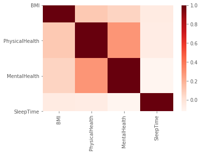

```python
sns.heatmap(df.corr(), cmap = 'Reds')
```

# PART C: DATA VISUALIZATION

```python
df['HeartDisease'].value_counts()
```

```
No     292422
Yes     27373
Name: HeartDisease, dtype: int64
```

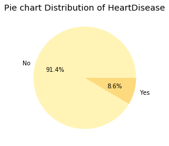

```python
plt.pie(df['HeartDisease'].value_counts(), labels = ["No","Yes"], colors = sns.color_palette("YlOrBr"), autopct = '%1.1f%%')
plt.title("Pie chart Distribution of HeartDisease")
plt.show()
pass
```

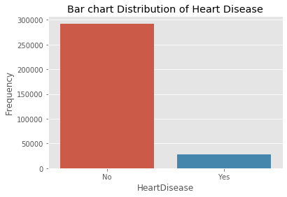

```python
sns.countplot( x = "HeartDisease", data=df)
plt.xlabel("HeartDisease")
plt.ylabel("Frequency")
plt.title("Bar chart Distribution of Heart Disease")
plt.show()
```

```python
Freq = df['Smoking'].value_counts()
Per= df['Smoking'].value_counts()/sum(Freq)*100
print(Freq)
print(Per)
```

```
No     187887
Yes    131908
Name: Smoking, dtype: int64
No     58.752326
Yes    41.247674
Name: Smoking, dtype: float64
```

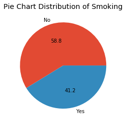

```python
ax = Freq.plot.pie(autopct='%.1f', labels = ["No", "Yes"])
ax.set_title('Pie Chart Distribution of Smoking')
ax.set_aspect(1)
ax.set_ylabel('')
```

```
No     298018
Yes     21777
Name: AlcoholDrinking, dtype: int64
No     93.190325
Yes     6.809675
Name: AlcoholDrinking, dtype: float64
```

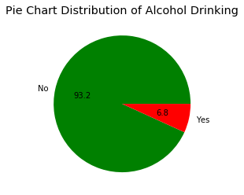

```python
Freq = df['AlcoholDrinking'].value_counts()
Per= df['AlcoholDrinking'].value_counts()/sum(Freq)*100
print(Freq)
print(Per)
ax = Freq.plot.pie(autopct='%.1f', labels = ["No", "Yes"], colors = ['Green','Red'])
ax.set_title('Pie Chart Distribution of Alcohol Drinking')
ax.set_aspect(1)
ax.set_ylabel('')
```

```
Female    167805
Male      151990
Name: Sex, dtype: int64
Female    52.472678
Male      47.527322
Name: Sex, dtype: float64
```

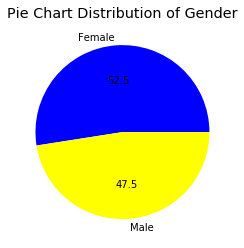

```python
Freq = df['Sex'].value_counts()
Per= df['Sex'].value_counts()/sum(Freq)*100
print(Freq)
print(Per)
ax = Freq.plot.pie(autopct='%.1f', labels = ["Female", "Male"], colors = ['Blue', 'Yellow'])
ax.set_title('Pie Chart Distribution of Gender')
ax.set_aspect(1)
ax.set_ylabel('')
```

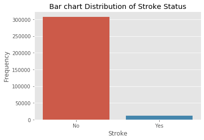

```python
sns.countplot( x = "Stroke", data=df )
plt.xlabel("Stroke")
plt.ylabel("Frequency")
plt.title("Bar chart Distribution of Stroke Status")
plt.show()
```

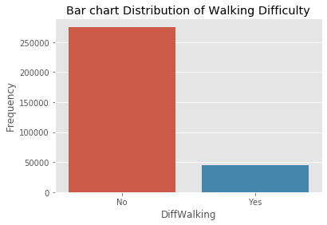

```python
sns.countplot( x = "DiffWalking", data=df )
plt.xlabel("DiffWalking")
plt.ylabel("Frequency")
plt.title("Bar chart Distribution of Walking Difficulty")
plt.show()
```

```
No     275385
Yes     44410
Name: DiffWalking, dtype: int64
No     86.112979
Yes    13.887021
Name: DiffWalking, dtype: float64
```

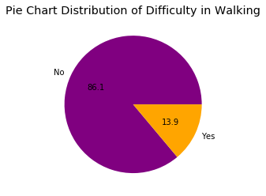

```python
Freq = df['DiffWalking'].value_counts()
Per= df['DiffWalking'].value_counts()/sum(Freq)*100
print(Freq)
print(Per)
ax = Freq.plot.pie(autopct='%.1f', labels = ["No", "Yes"], colors = ['Purple', 'Orange'])
ax.set_title('Pie Chart Distribution of Difficulty in Walking')
ax.set_aspect(1)
ax.set_ylabel('')
```

```python
Freq = df['AgeCategory'].value_counts()
Per= df['AgeCategory'].value_counts()/sum(Freq)*100
print(Freq)
print(Per)
```

```
65-69          34151
60-64          33686
70-74          31065
55-59          29757
50-54          25382
80 or older    24153
45-49          21791
75-79          21482
18-24          21064
40-44          21006
35-39          20550
30-34          18753
25-29          16955
Name: AgeCategory, dtype: int64
65-69          10.679029
60-64          10.533623
70-74           9.714036
55-59           9.305024
50-54           7.936960
80 or older     7.552651
45-49           6.814053
75-79           6.717428
18-24           6.586720
40-44           6.568583
35-39           6.425992
30-34           5.864069
25-29           5.301834
Name: AgeCategory, dtype: float64
```

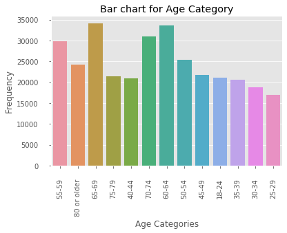

```python
sns.countplot( x = "AgeCategory", data=df )
plt.xlabel("AgeCategory")
plt.ylabel("Frequency")

plt.title("Bar chart for Age Category")
plt.xticks(rotation = 90)
plt.xlabel('Age Categories', size=12, labelpad=5)
# plt.legend(prop={'size': 10})
plt.tick_params(axis='x', labelsize=10, pad=15)
plt.tick_params(axis='y', labelsize=10, pad=15)


plt.show()
```

```
Very good    113858
Good          93129
Excellent     66842
Fair          34677
Poor          11289
Name: GenHealth, dtype: int64
Very good    35.603433
Good         29.121468
Excellent    20.901515
Fair         10.843509
Poor          3.530074
Name: GenHealth, dtype: float64
```

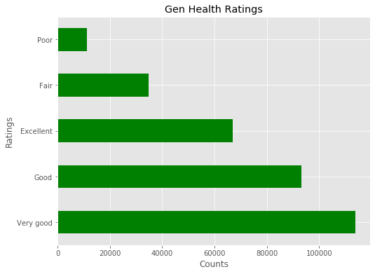

```python
Freq = df['GenHealth'].value_counts()
Per= df['GenHealth'].value_counts()/len(df['GenHealth'])*100
print(Freq)
print(Per)
fig = plt.subplots(figsize = (8, 6))
Freq.plot.barh(color = "green")
plt.title("Gen Health Ratings")
plt.xlabel('Counts')
plt.ylabel('Ratings')
```

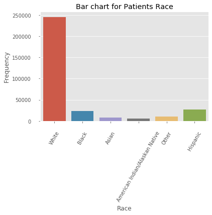

```python
sns.countplot( x = "Race", data=df )
plt.xlabel("Race")
plt.ylabel("Frequency")

plt.title("Bar chart for Patients Race")
plt.xticks(rotation = 60)
plt.xlabel('Race', size=12, labelpad=5)
# plt.legend(prop={'size': 10})
plt.tick_params(axis='x', labelsize=10, pad=15)
plt.tick_params(axis='y', labelsize=10, pad=15)


plt.show()
```

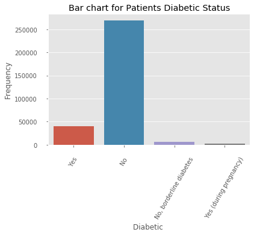

```python
sns.countplot( x = "Diabetic", data=df )
plt.xlabel("Diabetic")
plt.ylabel("Frequency")

plt.title("Bar chart for Patients Diabetic Status")
plt.xticks(rotation = 60)
plt.xlabel('Diabetic ', size=12, labelpad=5)
# plt.legend(prop={'size': 10})
plt.tick_params(axis='x', labelsize=10, pad=15)
plt.tick_params(axis='y', labelsize=10, pad=15)


plt.show()
```

```
Yes    247957
No      71838
Name: PhysicalActivity, dtype: int64
Yes    77.536234
No     22.463766
Name: PhysicalActivity, dtype: float64
```

[figure not shown]

```python
Freq = df['PhysicalActivity'].value_counts()
Per= df['PhysicalActivity'].value_counts()/sum(Freq)*100
print(Freq)
print(Per)
ax = Freq.plot.pie(autopct='%.1f', labels = ["No", "Yes", ], colors = ['Pink', 'Orange'])
ax.set_title('Pie Chart Distribution of Physical Activity')
ax.set_aspect(1)
ax.set_ylabel('')
```

```
No     276923
Yes     42872
Name: Asthma, dtype: int64
No     86.593912
Yes    13.406088
Name: Asthma, dtype: float64
```

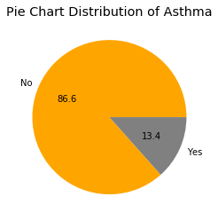

```python
Freq = df['Asthma'].value_counts()
Per= df['Asthma'].value_counts()/sum(Freq)*100
print(Freq)
print(Per)
ax = Freq.plot.pie(autopct='%.1f', labels = ["No", "Yes", ], colors = ['Orange','Grey'])
ax.set_title('Pie Chart Distribution of Asthma')
ax.set_aspect(1)
ax.set_ylabel('')
```

```
No     308016
Yes     11779
Name: KidneyDisease, dtype: int64
No     96.316703
Yes     3.683297
Name: KidneyDisease, dtype: float64
```

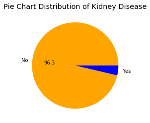

```python
Freq = df['KidneyDisease'].value_counts()
Per= df['KidneyDisease'].value_counts()/sum(Freq)*100
print(Freq)
print(Per)
ax = Freq.plot.pie(autopct='%.1f', labels = ["No", "Yes", ], colors = ['Orange','Blue'])
ax.set_title('Pie Chart Distribution of Kidney Disease')
ax.set_aspect(1)
ax.set_ylabel('')
```

```
No     289976
Yes     29819
Name: SkinCancer, dtype: int64
No     90.675589
Yes     9.324411
Name: SkinCancer, dtype: float64
```

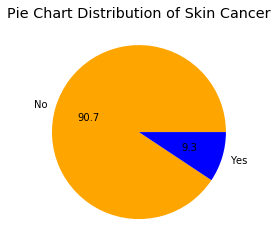

```python
Freq = df['SkinCancer'].value_counts()
Per= df['SkinCancer'].value_counts()/sum(Freq)*100
print(Freq)
print(Per)
ax = Freq.plot.pie(autopct='%.1f', labels = ["No", "Yes", ], colors = ['Orange','Blue'])
ax.set_title('Pie Chart Distribution of Skin Cancer')
ax.set_aspect(1)
ax.set_ylabel('')
```

## Quantitative Variables

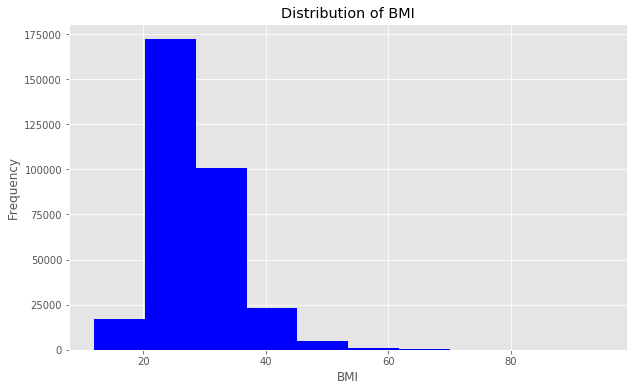

```python
fig = plt.subplots(figsize = (10, 6))
ps = df["BMI"].hist(color="Blue")
ps.set_xlabel('BMI')
ps.set_ylabel('Frequency')
ps.set_title('Distribution of BMI')
```

### Just Added

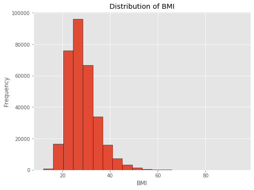

```python
# Histogram of MPG: This plot will show the distribution of fuel efficiency values.
plt.figure(figsize=(8, 6))
plt.hist(df['BMI'], bins=20, edgecolor='black')
plt.xlabel('BMI')
plt.ylabel('Frequency')
plt.title('Distribution of BMI')
plt.show()
```

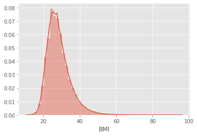

```python
sns.distplot(df['BMI'])
```

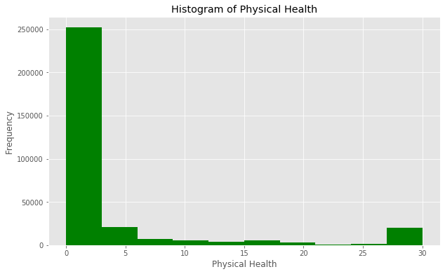

```python
fig = plt.subplots(figsize = (10, 6))
ps = df["PhysicalHealth"].hist(color="green")
ps.set_xlabel('Physical Health')
ps.set_ylabel('Frequency')
ps.set_title('Histogram of Physical Health')
```

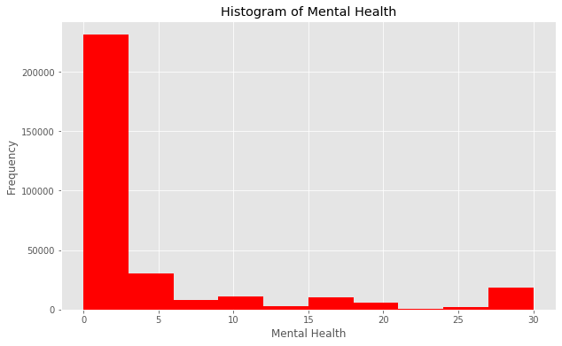

```python
fig = plt.subplots(figsize = (10, 6))
ps = df["MentalHealth"].hist(color="red")
ps.set_xlabel('Mental Health')
ps.set_ylabel('Frequency')
ps.set_title('Histogram of Mental Health')
```

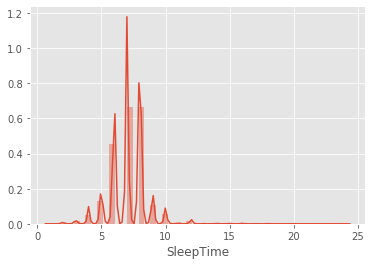

```python
sns.distplot(df['SleepTime'])
```

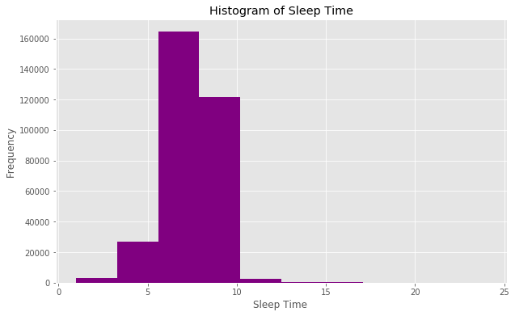

```python
fig = plt.subplots(figsize = (10, 6))
ps = df["SleepTime"].hist(color="purple")
ps.set_xlabel('Sleep Time ')
ps.set_ylabel('Frequency')
ps.set_title('Histogram of Sleep Time')
```

## BI-VARIATE PLOTS

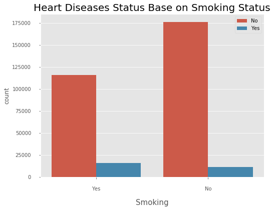

```python
fig = plt.subplots(figsize = (8, 6))

sns.countplot(hue ="HeartDisease", x = "Smoking", data = df)
plt.title("Heart Diseases Status Base on Smoking Status",  size=20)
# plt.xticks(rotation = 90)
plt.xlabel('Smoking', size=15, labelpad=15)
plt.legend(prop={'size': 10})
plt.tick_params(axis='x', labelsize=10, pad=15)
plt.tick_params(axis='y', labelsize=10, pad=15)
plt.show()
```

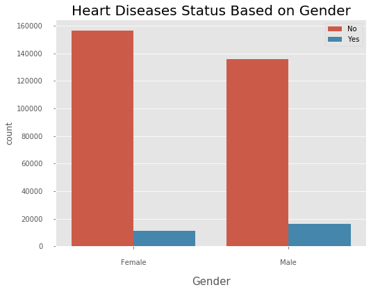

```python
fig = plt.subplots(figsize = (8, 6))

sns.countplot(hue ="HeartDisease", x = "Sex", data = df)
plt.title("Heart Diseases Status Based on Gender",  size=20)
# plt.xticks(rotation = 90)
plt.xlabel('Gender', size=15, labelpad=15)
plt.legend(prop={'size': 10})
plt.tick_params(axis='x', labelsize=10, pad=15)
plt.tick_params(axis='y', labelsize=10, pad=15)
plt.show()
```

```python
# color_labels = df['AlcoholDrinking'].unique
# rgb_values = sns.color_palette("Set2", 6)
# color_map = dict(zip(color_labels, rgb_values))
```

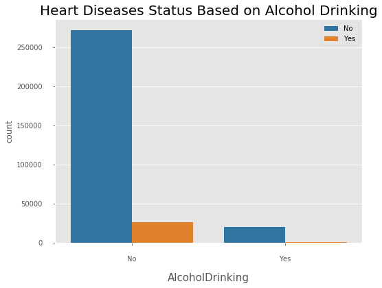

```python
fig = plt.subplots(figsize = (8, 6))
sns.countplot(hue ="HeartDisease", x = "AlcoholDrinking", data = df, palette='tab10')
plt.title("Heart Diseases Status Based on Alcohol Drinking",  size=20)
# plt.xticks(rotation = 90)
plt.xlabel('AlcoholDrinking', size=15, labelpad=15)
plt.legend(prop={'size': 10})
plt.tick_params(axis='x', labelsize=10, pad=15)
plt.tick_params(axis='y', labelsize=10, pad=15)
plt.show()
```

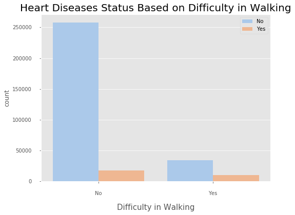

```python
fig = plt.subplots(figsize = (8, 6))
sns.countplot(hue ="HeartDisease", x = "DiffWalking", data = df, palette='pastel')
plt.title("Heart Diseases Status Based on Difficulty in Walking",  size=20)
# plt.xticks(rotation = 90)
plt.xlabel('Difficulty in Walking', size=15, labelpad=15)
plt.legend(prop={'size': 10})
plt.tick_params(axis='x', labelsize=10, pad=15)
plt.tick_params(axis='y', labelsize=10, pad=15)
plt.show()
```

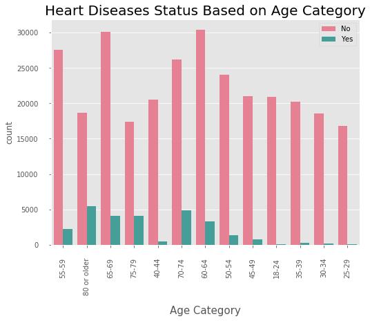

```python
fig = plt.subplots(figsize = (8, 6))
sns.countplot(hue ="HeartDisease", x = "AgeCategory", data = df, palette='husl')
plt.title("Heart Diseases Status Based on Age Category",  size=20)
plt.xticks(rotation = 90)
plt.xlabel('Age Category', size=15, labelpad=15)
plt.legend(prop={'size': 10})
plt.tick_params(axis='x', labelsize=10, pad=15)
plt.tick_params(axis='y', labelsize=10, pad=15)
plt.show()
```

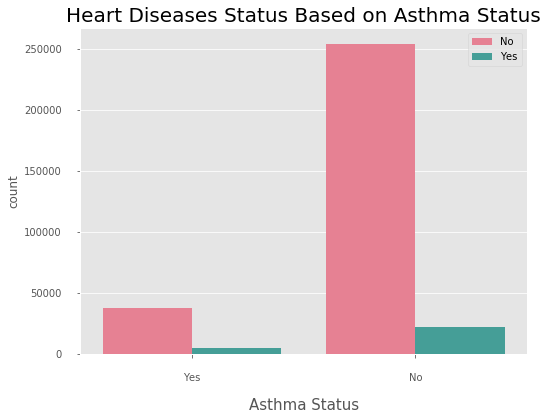

```python
fig = plt.subplots(figsize = (8, 6))
sns.countplot(hue ="HeartDisease", x = "Asthma", data = df, palette='husl')
plt.title("Heart Diseases Status Based on Asthma Status",  size=20)
# plt.xticks(rotatin = 90)
plt.xlabel('Asthma Status', size=15, labelpad=15)
plt.legend(prop={'size': 10})
plt.tick_params(axis='x', labelsize=10, pad=15)
plt.tick_params(axis='y', labelsize=10, pad=15)
plt.show()
```